HDBSCAN Un algoritmo de clustering jerárquico basado en densidad Edgar De la Cruz Bustamante, Corina Navarrete Macedo, Jean Paul Villanueva Soto 06 de Junio, 2025

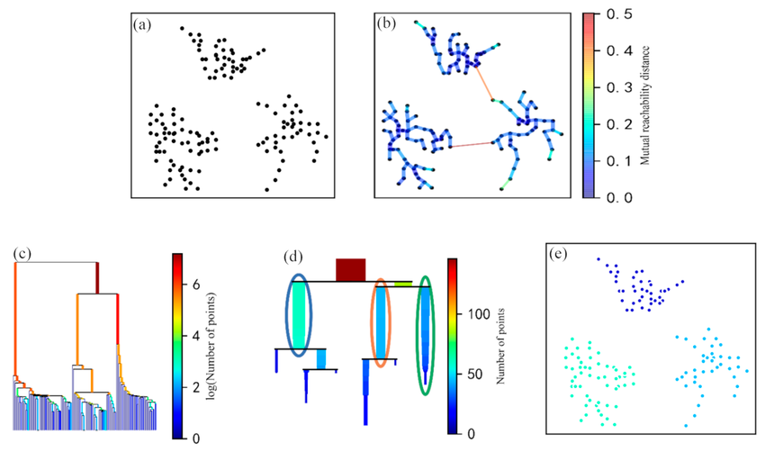

**📊 Profesor: Jesús Salinas**  
**📊 Curso: Reconocimiento de Patrones**  
**📊 Maestría en Estadística Aplicada**

# 1 INTRODUCCIÓN

En escenarios del mundo real, los conjuntos de datos suelen presentar una estructura compleja que desafía los supuestos de muchos algoritmos clásicos de agrupamiento. Es razonable esperar que los clústeres presentes tengan formas y tamaños arbitrarios, que varíen en densidad local, y que además existan puntos atípicos o de ruido dispersos entre ellos. Esta combinación de características hace que los métodos tradicionales de clustering, como K-means o clustering jerárquico aglomerativo con distancias euclidianas, resulten insuficientes, ya que tienden a generar clústeres esféricos, homogéneos y sensibles al ruido.

DBSCAN (Density-Based Spatial Clustering of Applications with Noise) fue una respuesta poderosa a estas limitaciones, al introducir un criterio de agrupamiento basado en densidad. Sin embargo, DBSCAN asume que la densidad local es aproximadamente uniforme en todo el espacio, lo cual es controlado por su parámetro eps. Esta suposición global no siempre se ajusta a la realidad: cuando los clústeres tienen densidades variables, el uso de un único valor de eps puede generar resultados erróneos, como la fusión de clústeres distintos o la omisión de agrupaciones válidas. Para superar esta limitación, surge HDBSCAN (Hierarchical DBSCAN), un algoritmo que extiende DBSCAN y combina la robustez del agrupamiento por densidad con una estructura jerárquica y una estrategia automatizada de selección de clústeres basada en su estabilidad.

HDBSCAN fue propuesto por Campello, Moulavi y Sander en el año 2013, y formalizado computacionalmente en 2015 como una extensión jerárquica y robusta de DBSCAN. Entre sus principales ventajas se encuentran su capacidad para detectar clústeres de densidad variable, identificar formas arbitrarias, y clasificar puntos de ruido sin intervención manual. Además, no requiere definir un valor fijo de eps, sino que utiliza una jerarquía basada en densidad para extraer automáticamente los clústeres más estables. Por otro lado, entre sus desventajas se puede mencionar que es computacionalmente más costoso que DBSCAN, especialmente en conjuntos de datos muy grandes, y que la interpretación de sus parámetros (como min_cluster_size y min_samples) puede no ser trivial en aplicaciones específicas. Aun así, HDBSCAN se ha consolidado como una de las alternativas más flexibles y efectivas para el clustering no supervisado en contextos reales complejos.

En la figura 1, se muestra cómo el algoritmo DBSCAN asume densidad uniforme en los datos, controlada por el parámetro eps. Cuando se aplica a un conjunto con forma no convexa o densidad variable, puede unir erróneamente clústeres distintos o fragmentar clústeres verdaderos, ya que la misma configuración no se adapta bien a regiones con distintas distribuciones de puntos.

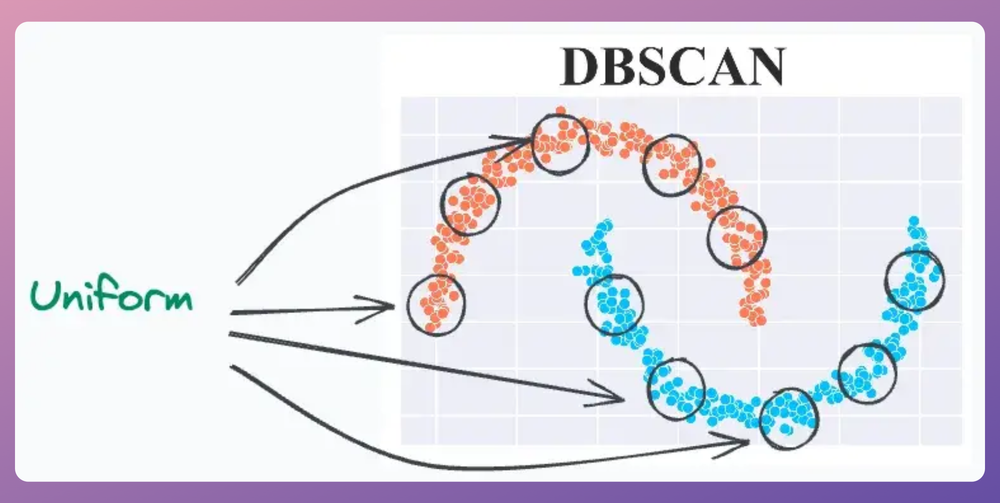

Figura 1. Supuesto de densidad uniforme en DBSCAN y sus efectos en formas complejas.

Fuente: https://blog.dailydoseofds.com/p/hdbscan-vs-dbscan

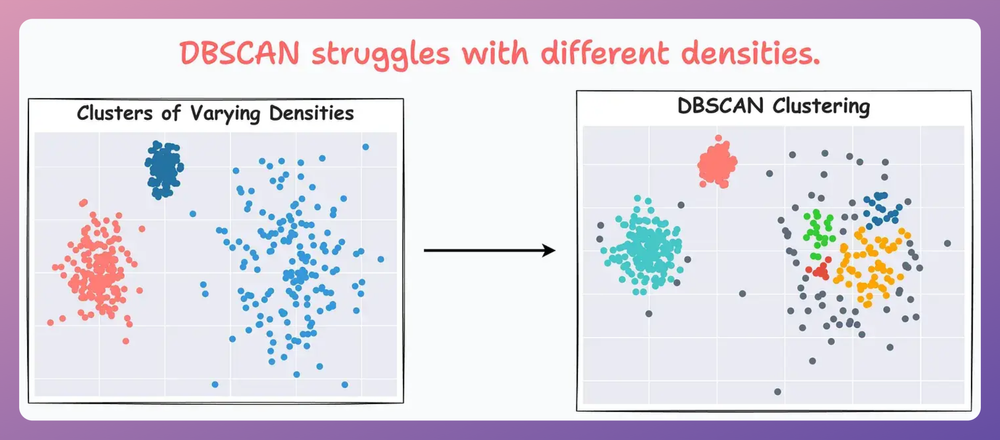

Figura 2. Limitaciones de DBSCAN al aplicar un único umbral de densidad.

Fuente: https://blog.dailydoseofds.com/p/hdbscan-vs-dbscan

En la figura 3, se ilustra cómo HDBSCAN logra detectar correctamente los clústeres con distintas densidades sin necesidad de ajustar manualmente un umbral global. Gracias a su análisis jerárquico de densidad y selección basada en estabilidad, puede adaptarse a la estructura interna de los datos y diferenciar agrupaciones válidas incluso cuando DBSCAN falla.

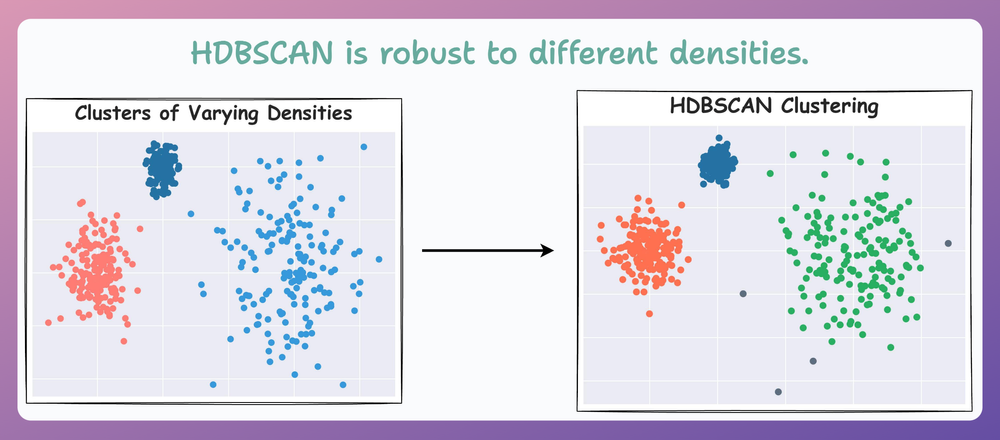

Figura 3. Agrupamiento correcto de HDBSCAN en presencia de densidades variables.

Fuente: https://blog.dailydoseofds.com/p/hdbscan-vs-dbscan

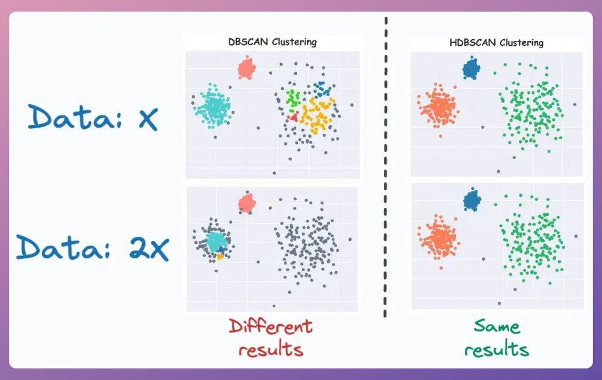

Figura 4. Comparación de resultados de DBSCAN y HDBSCAN ante cambios en la escala de los datos.

Fuente: https://blog.dailydoseofds.com/p/hdbscan-vs-dbscan

# 2 METODOLOGÍA

Para hallar los clústeres óptimos, HDBSCAN emplea una series de pasos. El primer paso transforma el espacio de datos mediante una métrica llamada distancia de alcance mutua. Luego, en el segundo paso, se construye un árbol de expansión mínima (MST) que conecta todos los puntos del conjunto utilizando esta métrica, asegurando una representación eficiente de la estructura de conectividad. El tercer paso genera una jerarquía de clústeres simulando la fusión de componentes conectados a medida que se incrementa el umbral de densidad. Posteriormente, el cuarto paso condensa dicha jerarquía, eliminando subdivisiones triviales y puntos que no forman agrupaciones significativas, lo que da lugar a un árbol condensado más interpretable. Finalmente, en el quinto paso, HDBSCAN extrae los clústeres óptimos utilizando una medida de estabilidad, manteniendo clústeres estables.

## Transformando el espacio

El primer paso de HDBSCAN consiste en transformar el espacio original de los datos para incorporar información sobre la densidad local de cada punto. Para ello, se calcula la **core distance**, definida como la distancia mínima a la que un punto debe expandirse para alcanzar al menos un número $k$ de vecinos. Esta medida permite identificar regiones densas y distinguirlas de zonas dispersas. A partir de las core distances y de las distancias originales entre pares de puntos, se define la **distancia de alcance mutua** (*mutual reachability distance*), que se calcula como:

$$d_{\text{mreach}-k}(a, b) = \max \left\{ \text{core}_k(a),
\text{core}_k(b), d(a, b) \right\}$$

Esta métrica garantiza que los puntos en regiones de baja densidad se alejen artificialmente, mientras que los puntos en zonas densas conserven su proximidad.

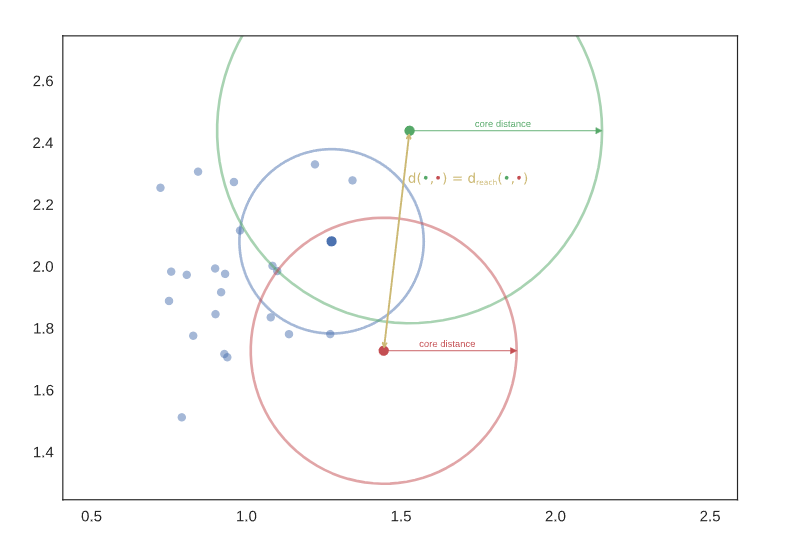

Figura 5. Cálculo de la distancia de alcance mutua entre dos puntos a partir de sus core distances.

Fuente: https://hdbscan.readthedocs.io/en/latest/how_hdbscan_works.html

## Construcción del arbol de expansión mínimo

En esta etapa, teniendo ya calculada la distancia de alcance mutua entre todos los pares de puntos, se procede a construir un grafo completo donde cada nodo representa un punto del conjunto de datos y cada arista está ponderada con dicha distancia. A partir de este grafo, se genera el árbol de expansión mínima (Minimum Spanning Tree, MST), que es un subgrafo acíclico que conecta todos los puntos utilizando la suma mínima posible de distancias. Este árbol se construye mediante algoritmos clásicos como el de Prim o Borůvka, y cumple una función fundamental: preservar únicamente las conexiones esenciales entre puntos, descartando aquellas redundantes que podrían introducir ruido o distorsionar la estructura de los clústeres.

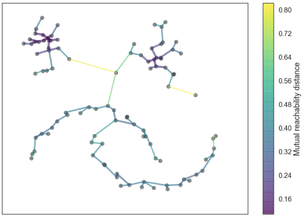

Figura 6. Árbol de expansión mínima ponderado por la distancia de alcance mutua entre puntos.

Fuente: https://hdbscan.readthedocs.io/en/latest/how_hdbscan_works.html

## Construir la jerarquía del clúster

Con base en el árbol de expansión mínima construido en la etapa anterior, HDBSCAN procede a generar una jerarquía de clústeres utilizando un enfoque inspirado en el método single linkage. Para ello, las aristas del árbol se ordenan en función creciente de la distancia de alcance mutua, y se van eliminando progresivamente. El resultado de este proceso es una estructura jerárquica que contiene todas las posibles agrupaciones que podrían surgir en el conjunto de datos bajo diferentes niveles de densidad. Esta jerarquía es análoga a un dendrograma, pero adaptado a datos con formas y densidades arbitrarias. Sin embargo, no todas las divisiones en la jerarquía representan clústeres significativos, por lo que es necesario aplicar un paso posterior para condensar esta estructura y extraer agrupaciones verdaderamente estables.

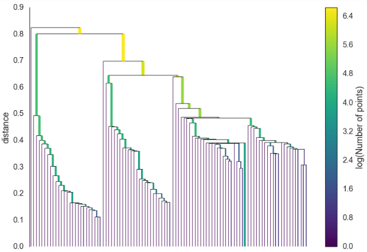

Figura 7. Jerarquía de clústeres generada mediante single linkage a partir del árbol de expansión mínima.

Fuente: https://hdbscan.readthedocs.io/en/latest/how_hdbscan_works.html

## Condensar el árbol de clústeres

En esta etapa se condensa la jerarquía de clústeres en una estructura más simple llamada árbol condensado. Muchas divisiones en la jerarquía no representan verdaderas particiones, sino la pérdida progresiva de puntos desde un clúster principal. Para distinguir divisiones reales, se aplica el criterio del tamaño mínimo de clúster.Una vez definido este umbral, se recorre la jerarquía de forma descendente y, en cada división, se evalúa si alguna de las ramas resultantes contiene menos puntos que min_cluster_size. Si es así, dichos puntos se consideran como puntos que abandonan el clúster principal, y la rama mayor conserva la identidad del clúster padre. En cambio, si ambas ramas resultantes superan el tamaño mínimo, se interpreta como una división legítima del clúster. Al finalizar este proceso, se obtiene un árbol condensado más pequeño, donde cada nodo contiene información sobre el número de puntos activos en distintos niveles de densidad.

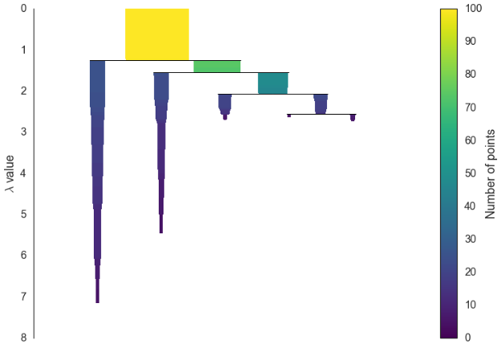

Figura 8. Árbol condensado generado por HDBSCAN para visualizar la persistencia y estabilidad de los clústeres.

Fuente: https://hdbscan.readthedocs.io/en/latest/how_hdbscan_works.html

## Extraer los clústeres

En esta etapa se seleccionan los **clústeres finales** a partir del árbol condensado, utilizando como criterio su **estabilidad**. Cada clúster se define en un intervalo de densidad representado por $\lambda$, donde $\lambda = \frac{1}{\text{distancia de alcance mutua}}$. Cuanto mayor sea $\lambda$, mayor es la densidad. Para cada clúster, se registra el valor $\lambda_{\text{birth}}$, correspondiente al nivel en que nace, y $\lambda_{\text{death}}$, cuando desaparece por división o por pérdida de puntos. A su vez, para cada punto $p$ que pertenece al clúster, se define $\lambda_p$ como el valor en que ese punto lo abandona.

Con esta información, la **estabilidad** de un clúster se calcula como:

$$\text{Estabilidad}(C) = \sum_{p \in C} (\lambda_p -
\lambda_{\text{birth}})$$

HDBSCAN recorre el árbol condensado en orden inverso y compara la estabilidad de cada clúster con la suma de las estabilidades de sus hijos. Si un clúster tiene mayor estabilidad que sus descendientes, se selecciona como válido y se descartan sus ramas inferiores. Del mismo modo, si los hijos de un clúster tienen mayor estabilidad en conjunto que el padre, se seleccionan los hijos y se descarta al padre. Esta regla garantiza que la partición final del conjunto de datos sea única, coherente y no solapada, manteniendo únicamente aquellas agrupaciones que hayan demostrado mayor persistencia a lo largo de los distintos niveles de densidad.Este proceso da lugar a una **partición plana del conjunto de datos**, donde solo se conservan los clústeres más persistentes. Los puntos que no pertenecen a ninguno de ellos se etiquetan como **ruido** (`label = -1`).

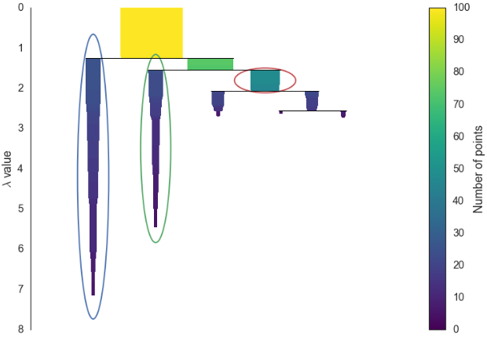

Figura 9. Clústeres extraídos en función de su estabilidad.

Fuente: https://hdbscan.readthedocs.io/en/latest/how_hdbscan_works.html

# 3 CASO PRÁCTICO

Tenemos 7 datos, se muestra su gráfica de dispersión:

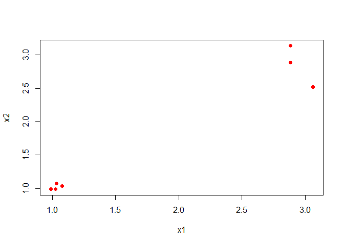

Los valores correspondientes a estos puntos se pueden ver en la siguiente tabla:

| Punto | x1 | x2 |
| --- | --- | --- |
| P0 | 1.0248 | 0.9931 |
| P1 | 1.0324 | 1.0762 |
| P2 | 0.9883 | 0.9883 |
| P3 | 1.0790 | 1.0384 |
| P4 | 2.8826 | 3.1356 |
| P5 | 2.8841 | 2.8836 |
| P6 | 3.0605 | 2.5217 |

De los cuales se calcula su core distance para cada punto, siendo un mínimo de 3 puntos que se debe alcanzar en su vecindario:

| Punto | Core Distance |
| --- | --- |
| P0 | 0.0706 |
| P1 | 0.0834 |
| P2 | 0.0983 |
| P3 | 0.0706 |
| P4 | 0.6392 |
| P5 | 0.4026 |
| P6 | 0.6392 |

Luego calculamos la distancia euclidiana entre los puntos P0 y P04:
$$\text{Distancia}(P_0, P_4) = \sqrt{(x_1^{(P_0)} - x_1^{(P_4)})^2 +
(x_2^{(P_0)} - x_2^{(P_4)})^2}
= \sqrt{(1.0248 - 2.8826)^2 + (0.9931 - 3.1356)^2} = 2.8358$$

También se muestra las distancias euclidianas entre todos los puntos:

|  | P0 | P1 | P2 | P3 | P4 | P5 | P6 |
| --- | --- | --- | --- | --- | --- | --- | --- |
| P0 | 0.0000 | 0.0834 | 0.0369 | 0.0706 | 2.8358 | 2.6516 | 2.5457 |
| P1 | 0.0834 | 0.0000 | 0.0983 | 0.0600 | 2.7686 | 2.5876 | 2.4905 |
| P2 | 0.0369 | 0.0983 | 0.0000 | 0.1036 | 2.8635 | 2.6807 | 2.5778 |
| P3 | 0.0706 | 0.0600 | 0.1036 | 0.0000 | 2.7662 | 2.5814 | 2.4752 |
| P4 | 2.8358 | 2.7686 | 2.8635 | 2.7662 | 0.0000 | 0.2521 | 0.6392 |
| P5 | 2.6516 | 2.5876 | 2.6807 | 2.5814 | 0.2521 | 0.0000 | 0.4026 |
| P6 | 2.5457 | 2.4905 | 2.5778 | 2.4752 | 0.6392 | 0.4026 | 0.0000 |

Siguiendo con el ejemplo de P0 y P4, calculamos la distancia de alcance mutua:
$$d_{\text{mreach}}(P_0, P_4) = \max \{ 0.0706,\ 0.6392,\ 2.8358 \} =
\boxed{2.8358}$$

En la tabla se muestra las distancias de alcance mutuo entre todos los puntos:

|  | P0 | P1 | P2 | P3 | P4 | P5 | P6 |
| --- | --- | --- | --- | --- | --- | --- | --- |
| P0 | 0.0000 | 0.0834 | 0.0983 | 0.0706 | 2.8358 | 2.6516 | 2.5457 |
| P1 | 0.0834 | 0.0000 | 0.0983 | 0.0834 | 2.7686 | 2.5876 | 2.4905 |
| P2 | 0.0983 | 0.0983 | 0.0000 | 0.1036 | 2.8635 | 2.6807 | 2.5778 |
| P3 | 0.0706 | 0.0834 | 0.1036 | 0.0000 | 2.7662 | 2.5814 | 2.4752 |
| P4 | 2.8358 | 2.7686 | 2.8635 | 2.7662 | 0.0000 | 0.6392 | 0.6392 |
| P5 | 2.6516 | 2.5876 | 2.6807 | 2.5814 | 0.6392 | 0.0000 | 0.6392 |
| P6 | 2.5457 | 2.4905 | 2.5778 | 2.4752 | 0.6392 | 0.6392 | 0.0000 |

El siguiente gráfico muestra la distancia de alcance mutua entre los puntos P0 y P4, que es de 2.84.

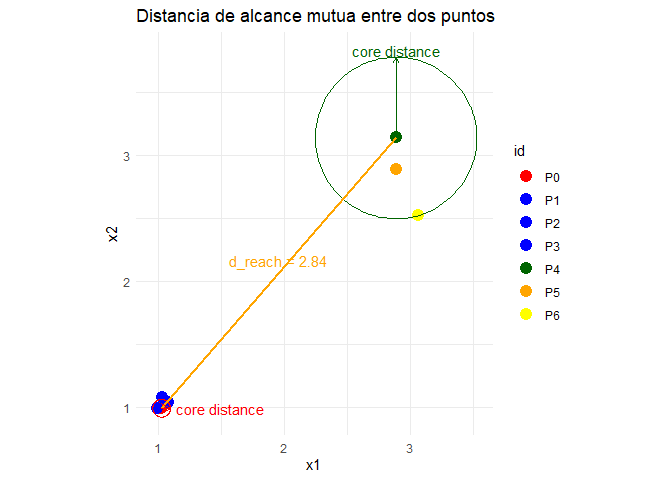

Visualizamos el árbol de expansión mínima (MST) obtenido a partir de la matriz de distancias de alcance mutua:

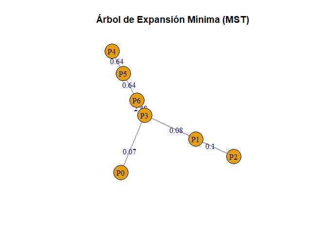

Posteriormente, se puede observar el árbol jerárquico de HDBSCAN:

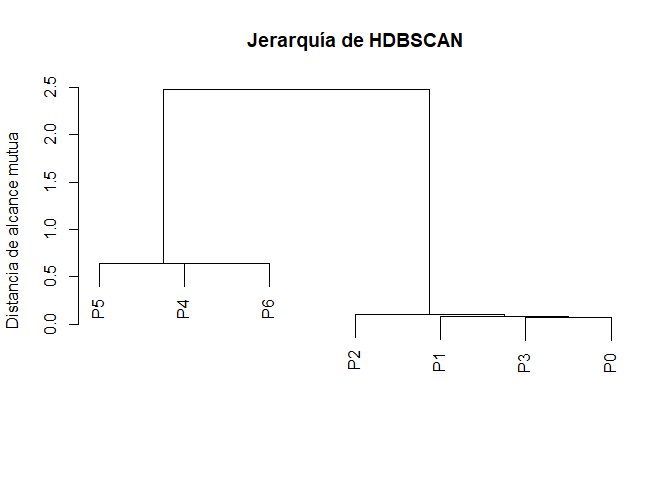

Obtenido el árbol jerárquico, se procede a obtener el árbol condensado y los cluster a extraer:

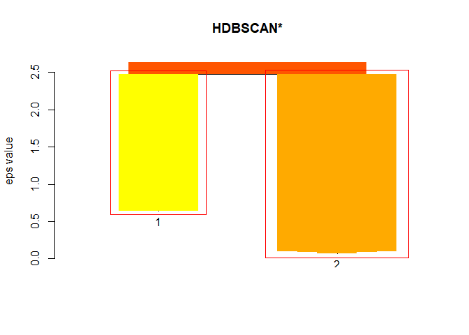

**🔎 Nota técnica:**  
Algunos programas como R muestran en el eje Y la etiqueta “eps value”, pero en realidad representan la distancia de alcance mutua.Teóricamente, debería usarse $\lambda$, que es la inversa de la distancia de alcance mutua. Sin embargo, la interpretación del eje se mantiene: en la parte superior está la menor densidad y hacia abajo, mayor densidad.

Finalmente se muestran los puntos agrupados por clústeres:

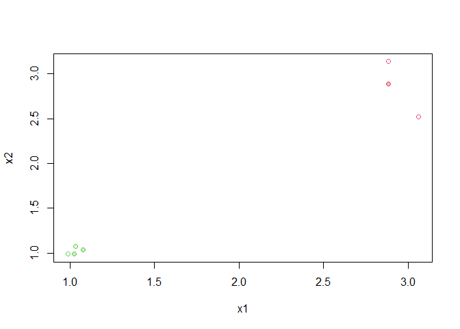

# 4 Implementación en R

Cargamos la libreria dbscan en el cual esta implementado para el uso de HDBSCAN

```r
library("dbscan")
```

Datos:

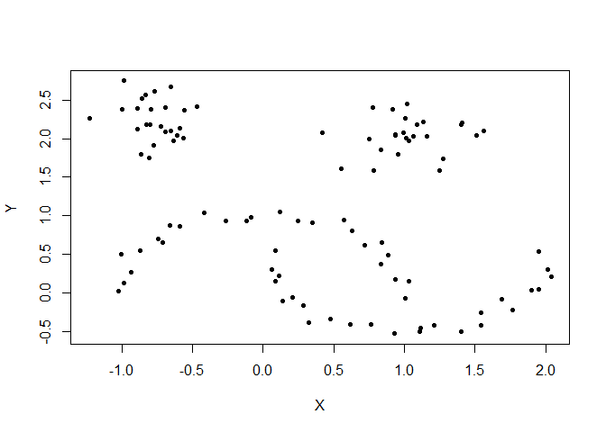

```r
data("moons")
plot(moons, pch=20)
```

Aplicación del algoritmo HDBSCAN Para ejecutar el algoritmo HDBSCAN, simplemente pase el conjunto de datos y el único valor de parámetro `.minPts` a la función hdbscan.

```r
cl <- hdbscan(moons, minPts = 5)
cl
```

```
## HDBSCAN clustering for 100 objects.
## Parameters: minPts = 5
## The clustering contains 3 cluster(s) and 0 noise points.
##
##  1  2  3
## 25 25 50
##
## Available fields: cluster, minPts, coredist, cluster_scores,
##                   membership_prob, outlier_scores, hc
```

Árbol jerárquico

Esta representación jerárquica se almacena compactamente en el familiar miembro de la HDBSCAN resultante objeto.

```r
cl$hc
```

```
##
## Call:
## hdbscan(x = moons, minPts = 5)
##
## Cluster method   : robust single
## Distance         : mutual reachability
## Number of objects: 100
```

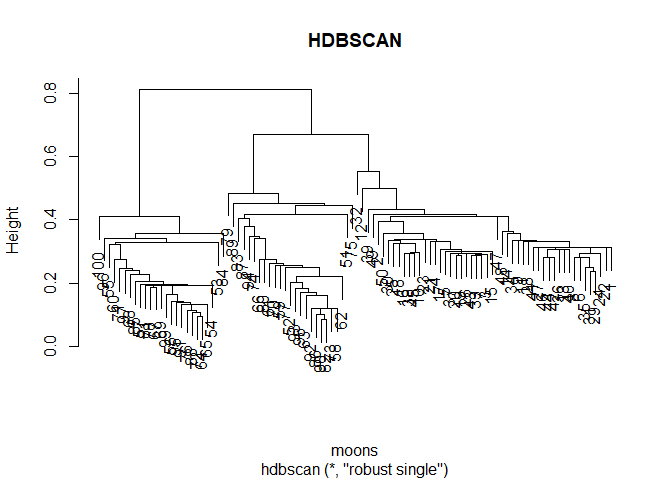

```r
plot(cl$hc, main="HDBSCAN")
```

A continuación se muestra el árbol condensado:

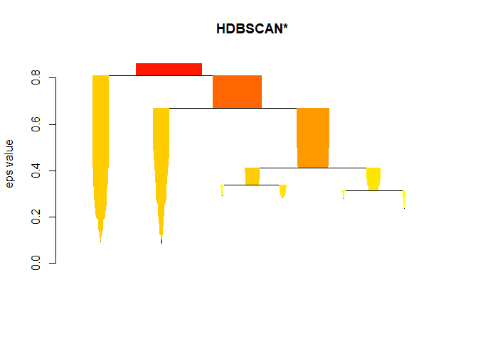

```r
plot(cl)
```

En este apartado se muestra la extracción de clústeres (los considerados estables):

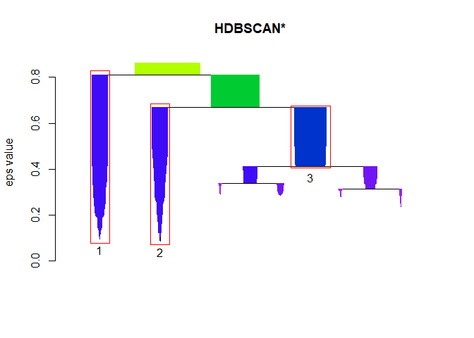

```r
plot(cl, gradient = c("purple", "blue", "green", "yellow"), show_flat = TRUE)
```

Finalmente se gráfica los puntos agrupados por clústeres, donde la intensidad de color se encuentra relacionada a la probabilidad de pertenencia a un clúster.

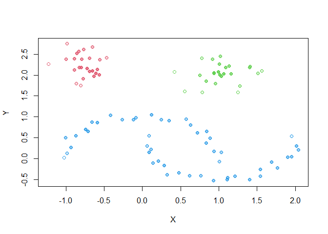

```r
plot(moons, col=cl$cluster+1, pch=21)
colors <- mapply(function(col, i) adjustcolor(col, alpha.f = cl$membership_prob[i]), palette()[cl$cluster+1], seq_along(cl$cluster))
points(moons, col=colors, pch=20)
```

**🧩 Extra:**  
La implementación de **HDBSCAN en Python** permite diferenciar entre dos parámetros: `min_samples`, que define el número de vecinos $k$ para estimar la densidad local, y `min_cluster_size`, que establece el tamaño mínimo para formar un clúster.  
En cambio, en **R**, el parámetro `minPts` cumple ambas funciones de forma simultánea, actuando tanto como estimador de densidad como criterio de tamaño mínimo de agrupación.

# 5 Caso de aplicación: Próximo paso

Para aplicar la comparación entre HDBSCAN y DBSCAN, se utilizará el conjunto de datos denominado “Students Performance in Exams”, disponible públicamente en la plataforma Kaggle mediante el siguiente [enlace](https://www.kaggle.com/datasets/spscientist/students-performance-in-exams). Este dataset contiene información sobre el rendimiento académico de estudiantes en tres materias (matemáticas, lectura y escritura), así como variables sociodemográficas relacionadas con el género, nivel educativo de los padres, tipo de almuerzo y preparación para el examen.

# 6 Referencias

- Daily Dose of Data Science. (2024). *HDBSCAN vs DBSCAN: Which is better and why?* Recuperado el 5 de junio de 2025, de https://blog.dailydoseofds.com/p/hdbscan-vs-dbscan
- McInnes, L., & Healy, J. (2016). *How HDBSCAN works*. Recuperado el 5 de junio de 2025, de https://hdbscan.readthedocs.io/en/latest/how_hdbscan_works.html